# 1.4 向量与矩阵的运算

授课教师: 李哲源，河南大学数学与统计学院

最后修改日期: 2023-02-27

R软件： 初学**R**语言可以不用安装该软件，不妨试试在线版本：https://rdrr.io/snippets/。

R程序文件：创建一个后缀名为”.R”的文件，比如”example.R”，然后用普通的记事本（notepad）打开。或者，安装一个更高级的记事本（notepad++）以获得更好的编程体验。

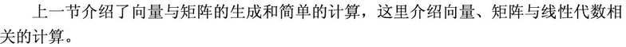

# 1.4.1 向量和矩阵的转置运算

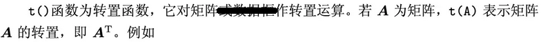

```r
A <- matrix(c(1:8, 0), nrow = 3); A
```

```
##      [,1] [,2] [,3]
## [1,]    1    4    7
## [2,]    2    5    8
## [3,]    3    6    0
```

```r
t(A)
```

```
##      [,1] [,2] [,3]
## [1,]    1    2    3
## [2,]    4    5    6
## [3,]    7    8    0
```

**R**中的向量等同于列向量，通过转置可以将其变为真正的行向量。

```r
x <- 1:4

t(x)
```

```
##      [,1] [,2] [,3] [,4]
## [1,]    1    2    3    4
```

# 1.4.2 向量的四则运算

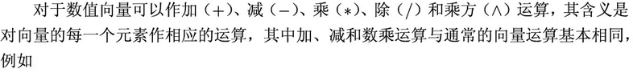

```r
x <- c(-1, 0, 2); y <- c(3, 8, 2)
v <- 2 * x + y + 1; v
```

```
## [1] 2 9 7
```

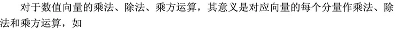

```r
x * y
```

```
## [1] -3  0  4
```

```r
x / y
```

```
## [1] -0.3333333  0.0000000  1.0000000
```

```r
x ^ 2
```

```
## [1] 1 0 4
```

```r
y ^ x
```

```
## [1] 0.3333333 1.0000000 4.0000000
```

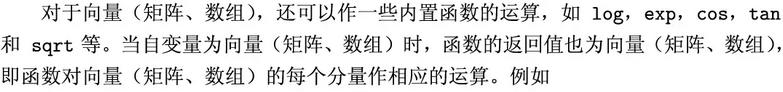

```r
exp(x)
```

```
## [1] 0.3678794 1.0000000 7.3890561
```

```r
sqrt(y)
```

```
## [1] 1.732051 2.828427 1.414214
```

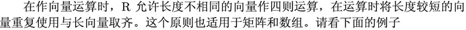

```r
x1 <- c(100, 200); x2 <- 1:6
x1 + x2
```

```
## [1] 101 202 103 204 105 206
```

```r
x3 <- matrix(11:16, nrow = 3)

x1 + x3
```

```
##      [,1] [,2]
## [1,]  111  214
## [2,]  212  115
## [3,]  113  216
```

```r
x2 + x3
```

```
##      [,1] [,2]
## [1,]   12   18
## [2,]   14   20
## [3,]   16   22
```

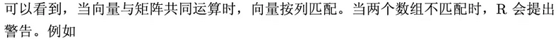

```r
x1 <- c(100, 200); x2 <- 1:5
x1 + x2
```

[output not shown]

# 1.4.3 向量的内积与外积

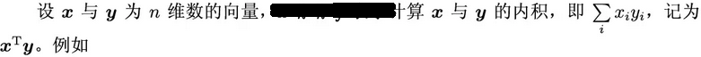

```r
x <- 1:5; y <- 2 * (1:5)

## OK，但结果是1 x 1的矩阵
t(x) %*% y
```

```
##      [,1]
## [1,]  110
```

```r
## 去掉其维度，变成向量/纯量
as.vector(t(x) %*% y)
```

```
## [1] 110
```

```r
## 另一种很常见的做法
sum(x * y)
```

```
## [1] 110
```

`%*%`是矩阵乘法运算，下面会单独再介绍。这里，`t(x) %*% y`是将向量内积看作行向量（单行矩阵）与列向量（单列矩阵）的矩阵乘法来做的。

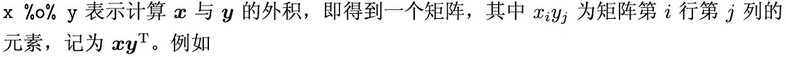

```r
x %*% t(y)
```

```
##      [,1] [,2] [,3] [,4] [,5]
## [1,]    2    4    6    8   10
## [2,]    4    8   12   16   20
## [3,]    6   12   18   24   30
## [4,]    8   16   24   32   40
## [5,]   10   20   30   40   50
```

```r
x %o% y
```

```
##      [,1] [,2] [,3] [,4] [,5]
## [1,]    2    4    6    8   10
## [2,]    4    8   12   16   20
## [3,]    6   12   18   24   30
## [4,]    8   16   24   32   40
## [5,]   10   20   30   40   50
```

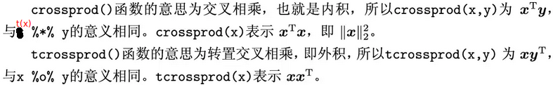

```r
crossprod(x, y)
```

```
##      [,1]
## [1,]  110
```

```r
as.vector(crossprod(x, y))
```

```
## [1] 110
```

```r
as.vector(crossprod(x))
```

```
## [1] 55
```

```r
tcrossprod(x, y)
```

```
##      [,1] [,2] [,3] [,4] [,5]
## [1,]    2    4    6    8   10
## [2,]    4    8   12   16   20
## [3,]    6   12   18   24   30
## [4,]    8   16   24   32   40
## [5,]   10   20   30   40   50
```

```r
tcrossprod(x)
```

```
##      [,1] [,2] [,3] [,4] [,5]
## [1,]    1    2    3    4    5
## [2,]    2    4    6    8   10
## [3,]    3    6    9   12   15
## [4,]    4    8   12   16   20
## [5,]    5   10   15   20   25
```

# 1.4.4 矩阵的四则运算和矩阵乘法

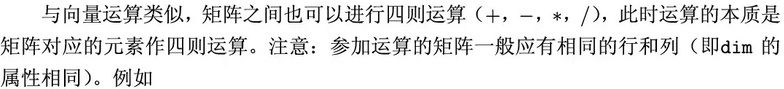

```r
A <- matrix(1:6, nrow = 2, byrow = TRUE); A
```

```
##      [,1] [,2] [,3]
## [1,]    1    2    3
## [2,]    4    5    6
```

```r
B <- matrix(1:6, nrow = 2); B
```

```
##      [,1] [,2] [,3]
## [1,]    1    3    5
## [2,]    2    4    6
```

```r
C <- matrix(c(1, 2, 2, 3, 3, 4), nrow = 2)

D <- 2 * C + A / B; D
```

```
##      [,1]     [,2] [,3]
## [1,]    3 4.666667  6.6
## [2,]    6 7.250000  9.0
```

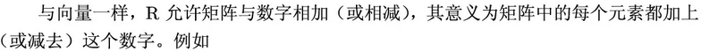

```r
A + 1
```

```
##      [,1] [,2] [,3]
## [1,]    2    3    4
## [2,]    5    6    7
```

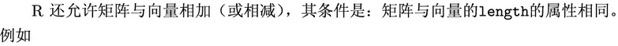

```r
x <- 1:6; A + x
```

```
##      [,1] [,2] [,3]
## [1,]    2    5    8
## [2,]    6    9   12
```

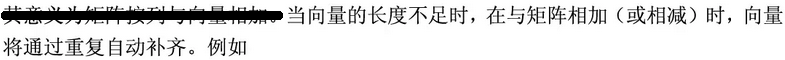

```r
y <- 1:2; A - y
```

```
##      [,1] [,2] [,3]
## [1,]    0    1    2
## [2,]    2    3    4
```

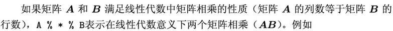

```r
A <- matrix(1:9, nrow = 3); A
```

```
##      [,1] [,2] [,3]
## [1,]    1    4    7
## [2,]    2    5    8
## [3,]    3    6    9
```

```r
B <- matrix(9:1, nrow = 3); B
```

```
##      [,1] [,2] [,3]
## [1,]    9    6    3
## [2,]    8    5    2
## [3,]    7    4    1
```

```r
C <- A %*% B; C
```

```
##      [,1] [,2] [,3]
## [1,]   90   54   18
## [2,]  114   69   24
## [3,]  138   84   30
```

```r
x <- 1:3

A %*% x
```

```
##      [,1]
## [1,]   30
## [2,]   36
## [3,]   42
```

```r
t(x) %*% A
```

```
##      [,1] [,2] [,3]
## [1,]   14   32   50
```

```r
t(x) %*% A %*% x
```

```
##      [,1]
## [1,]  228
```

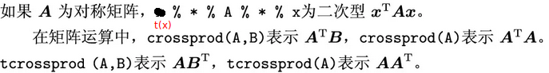

```r
## 同t(A) %*% B
crossprod(A, B)
```

```
##      [,1] [,2] [,3]
## [1,]   46   28   10
## [2,]  118   73   28
## [3,]  190  118   46
```

```r
## 同t(A) %*% A
crossprod(A)
```

```
##      [,1] [,2] [,3]
## [1,]   14   32   50
## [2,]   32   77  122
## [3,]   50  122  194
```

```r
## 同A %*% t(B)
tcrossprod(A, B)
```

```
##      [,1] [,2] [,3]
## [1,]   54   42   30
## [2,]   72   57   42
## [3,]   90   72   54
```

```r
## 同A %*% t(A)
tcrossprod(A)
```

```
##      [,1] [,2] [,3]
## [1,]   66   78   90
## [2,]   78   93  108
## [3,]   90  108  126
```

```r
## 同t(A) %*% x
crossprod(A, x)
```

```
##      [,1]
## [1,]   14
## [2,]   32
## [3,]   50
```

```r
## 同t(x) %*% A
crossprod(x, A)
```

```
##      [,1] [,2] [,3]
## [1,]   14   32   50
```

```r
## 同二次型t(x) %*% A %*% x
crossprod(x, A) %*% x
```

```
##      [,1]
## [1,]  228
```

# 1.4.5 巧用“循环法则”处理矩阵

将矩阵的每一行减去不同的数，比如每行的均值。

```r
A <- matrix(1:9, nrow = 3); A
```

```
##      [,1] [,2] [,3]
## [1,]    1    4    7
## [2,]    2    5    8
## [3,]    3    6    9
```

```r
m <- rowMeans(A)

B <- A - m

rowMeans(B)
```

```
## [1] 0 0 0
```

将矩阵的每一列减去不同的数，比如每列的均值。

```r
A <- matrix(1:9, nrow = 3); A
```

```
##      [,1] [,2] [,3]
## [1,]    1    4    7
## [2,]    2    5    8
## [3,]    3    6    9
```

```r
m <- colMeans(A)

C <- t(t(A) - m)

colMeans(C)
```

```
## [1] 0 0 0
```

在矩阵的左边乘一个对角矩阵（将矩阵的每一行乘以不同的数），比如除以每行的标准差。

```r
B
```

```
##      [,1] [,2] [,3]
## [1,]   -3    0    3
## [2,]   -3    0    3
## [3,]   -3    0    3
```

```r
x <- 1 / apply(B, 1, sd)

## 简单粗暴
diag(x) %*% B
```

```
##      [,1] [,2] [,3]
## [1,]   -1    0    1
## [2,]   -1    0    1
## [3,]   -1    0    1
```

```r
## 技巧
B * x
```

```
##      [,1] [,2] [,3]
## [1,]   -1    0    1
## [2,]   -1    0    1
## [3,]   -1    0    1
```

在矩阵的右边乘一个对角矩阵（将矩阵的每一列乘以不同的数），比如除以每列的标准差。

```r
C
```

```
##      [,1] [,2] [,3]
## [1,]   -1   -1   -1
## [2,]    0    0    0
## [3,]    1    1    1
```

```r
x <- 1 / apply(C, 2, sd)

## 简单粗暴
C %*% diag(x)
```

```
##      [,1] [,2] [,3]
## [1,]   -1   -1   -1
## [2,]    0    0    0
## [3,]    1    1    1
```

```r
## 技巧
t(t(C) * x)
```

```
##      [,1] [,2] [,3]
## [1,]   -1   -1   -1
## [2,]    0    0    0
## [3,]    1    1    1
```

# 1.4.6 方阵的行列式

```r
A <- matrix(c(1:8, 0), nrow = 3); A
```

```
##      [,1] [,2] [,3]
## [1,]    1    4    7
## [2,]    2    5    8
## [3,]    3    6    0
```

```r
det(A)
```

```
## [1] 27
```

这里可以跟大家说，计算机算出来的很小的数不一定应该是零。是零的例子：`sqrt(2) ^ 2 - 2`；不是零的例子`det(diag(0.1, nrow = 100))`.

# 1.4.7 求解线性方程组

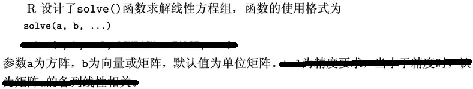

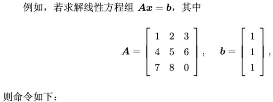

```r
A <- matrix(c(1:8, 0), nrow = 3, byrow = TRUE); A
```

```
##      [,1] [,2] [,3]
## [1,]    1    2    3
## [2,]    4    5    6
## [3,]    7    8    0
```

```r
b <- rep(1, 3); b
```

```
## [1] 1 1 1
```

```r
x <- solve(A, b); x
```

```
## [1] -1.000000e+00  1.000000e+00 -3.700743e-17
```

```r
B <- solve(A); B
```

```
##            [,1]       [,2]       [,3]
## [1,] -1.7777778  0.8888889 -0.1111111
## [2,]  1.5555556 -0.7777778  0.2222222
## [3,] -0.1111111  0.2222222 -0.1111111
```

```r
A %*% B
```

```
##               [,1]         [,2] [,3]
## [1,]  1.000000e+00 1.110223e-16    0
## [2,] -1.110223e-15 1.000000e+00    0
## [3,]  0.000000e+00 0.000000e+00    1
```

注意：`solve`只能处理满秩方阵。如果方阵不满秩，线性方程组可能无解或者没有唯一解，计算机无法处理。

```r
A <- tcrossprod(1:3); A
```

```
##      [,1] [,2] [,3]
## [1,]    1    2    3
## [2,]    2    4    6
## [3,]    3    6    9
```

```r
solve(A, b)
```

```
## Error in solve.default(A, b): Lapack routine dgesv: system is exactly singular: U[2,2] = 0
```

# 1.4.8 矩阵的分解

## 1.4.8-1 瘦高矩阵（行数 >= 列数）的QR分解

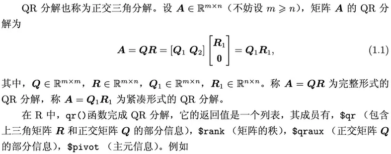

```r
A <- cbind(1, c(1, -1, 1)); A
```

```
##      [,1] [,2]
## [1,]    1    1
## [2,]    1   -1
## [3,]    1    1
```

```r
qrA <- qr(A); qrA
```

```
## $qr
##            [,1]       [,2]
## [1,] -1.7320508 -0.5773503
## [2,]  0.5773503  1.6329932
## [3,]  0.5773503 -0.2588190
##
## $rank
## [1] 2
##
## $qraux
## [1] 1.577350 1.965926
##
## $pivot
## [1] 1 2
##
## attr(,"class")
## [1] "qr"
```

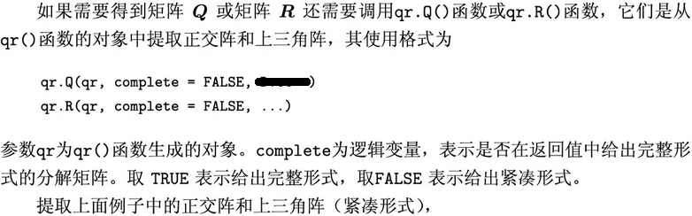

```r
Q1 <- qr.Q(qrA); Q1
```

```
##            [,1]       [,2]
## [1,] -0.5773503  0.4082483
## [2,] -0.5773503 -0.8164966
## [3,] -0.5773503  0.4082483
```

```r
R1 <- qr.R(qrA); R1
```

```
##           [,1]       [,2]
## [1,] -1.732051 -0.5773503
## [2,]  0.000000  1.6329932
```

```r
## 验证Q1有彼此正交的列（但没有彼此正交的行）
crossprod(Q1)
```

```
##               [,1]          [,2]
## [1,]  1.000000e+00 -5.551115e-17
## [2,] -5.551115e-17  1.000000e+00
```

```r
tcrossprod(Q1)
```

```
##              [,1]         [,2]         [,3]
## [1,] 5.000000e-01 5.551115e-17 5.000000e-01
## [2,] 5.551115e-17 1.000000e+00 1.110223e-16
## [3,] 5.000000e-01 1.110223e-16 5.000000e-01
```

```r
## 验证QR分解的正确性
A
```

```
##      [,1] [,2]
## [1,]    1    1
## [2,]    1   -1
## [3,]    1    1
```

```r
Q1 %*% R1
```

```
##      [,1] [,2]
## [1,]    1    1
## [2,]    1   -1
## [3,]    1    1
```

设定`complete = TRUE`。

```r
Q <- qr.Q(qrA, complete = TRUE); Q
```

```
##            [,1]       [,2]          [,3]
## [1,] -0.5773503  0.4082483 -7.071068e-01
## [2,] -0.5773503 -0.8164966 -1.110223e-16
## [3,] -0.5773503  0.4082483  7.071068e-01
```

```r
R <- qr.R(qrA, complete = TRUE); R
```

```
##           [,1]       [,2]
## [1,] -1.732051 -0.5773503
## [2,]  0.000000  1.6329932
## [3,]  0.000000  0.0000000
```

```r
## 验证Q有彼此正交的列，以及彼此正交的行
crossprod(Q)
```

```
##               [,1]          [,2]         [,3]
## [1,]  1.000000e+00 -5.551115e-17 1.110223e-16
## [2,] -5.551115e-17  1.000000e+00 0.000000e+00
## [3,]  1.110223e-16  0.000000e+00 1.000000e+00
```

```r
tcrossprod(Q)
```

```
##               [,1]         [,2]          [,3]
## [1,]  1.000000e+00 1.340158e-16 -1.110223e-16
## [2,]  1.340158e-16 1.000000e+00  3.251768e-17
## [3,] -1.110223e-16 3.251768e-17  1.000000e+00
```

```r
## 验证QR分解的正确性
A
```

```
##      [,1] [,2]
## [1,]    1    1
## [2,]    1   -1
## [3,]    1    1
```

```r
Q %*% R
```

```
##      [,1] [,2]
## [1,]    1    1
## [2,]    1   -1
## [3,]    1    1
```

## 1.4.8-2 任意矩阵的（紧凑）SVD分解

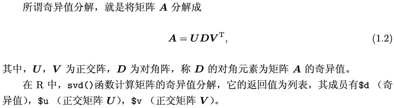

说明：书上介绍的完整的SVD分解，但**R**执行的紧凑的SVD分解。我们通过操作瘦高矩阵（行数 > 列数）和矮胖矩阵（行数 < 列数）来说明紧凑形式下U、D、V三个矩阵的特点。

先看一个瘦高矩阵。

```r
A <- cbind(1, c(1, -1, 1)); A
```

```
##      [,1] [,2]
## [1,]    1    1
## [2,]    1   -1
## [3,]    1    1
```

```r
svdA <- svd(A); svdA
```

```
## $d
## [1] 2.000000 1.414214
##
## $u
##               [,1]          [,2]
## [1,] -7.071068e-01  2.220446e-16
## [2,] -5.551115e-17 -1.000000e+00
## [3,] -7.071068e-01  2.220446e-16
##
## $v
##            [,1]       [,2]
## [1,] -0.7071068 -0.7071068
## [2,] -0.7071068  0.7071068
```

```r
## 验证分解的正确性（简单粗暴）
with(svdA, u %*% diag(d) %*% t(v))
```

```
##      [,1] [,2]
## [1,]    1    1
## [2,]    1   -1
## [3,]    1    1
```

```r
## 验证分解的正确性（巧用循环法则）
with(svdA, u %*% (d * t(v)))
```

```
##      [,1] [,2]
## [1,]    1    1
## [2,]    1   -1
## [3,]    1    1
```

```r
## 验证U有正交的列，没有正交的行
crossprod(svdA$u)
```

```
##               [,1]          [,2]
## [1,]  1.000000e+00 -2.585073e-16
## [2,] -2.585073e-16  1.000000e+00
```

```r
tcrossprod(svdA$u)
```

```
##               [,1]          [,2]          [,3]
## [1,]  5.000000e-01 -1.827923e-16  5.000000e-01
## [2,] -1.827923e-16  1.000000e+00 -1.827923e-16
## [3,]  5.000000e-01 -1.827923e-16  5.000000e-01
```

```r
## 验证V是正交矩阵
crossprod(svdA$v)
```

```
##      [,1] [,2]
## [1,]    1    0
## [2,]    0    1
```

```r
tcrossprod(svdA$v)
```

```
##      [,1] [,2]
## [1,]    1    0
## [2,]    0    1
```

再看一个矮胖矩阵。

```r
B <- t(A); B
```

```
##      [,1] [,2] [,3]
## [1,]    1    1    1
## [2,]    1   -1    1
```

```r
svdB <- svd(B); svdB
```

```
## $d
## [1] 2.000000 1.414214
##
## $u
##            [,1]       [,2]
## [1,] -0.7071068 -0.7071068
## [2,] -0.7071068  0.7071068
##
## $v
##               [,1]          [,2]
## [1,] -7.071068e-01  2.775558e-16
## [2,] -1.110223e-16 -1.000000e+00
## [3,] -7.071068e-01  2.775558e-16
```

```r
## 验证分解的正确性（简单粗暴）
with(svdB, u %*% diag(d) %*% t(v))
```

```
##      [,1] [,2] [,3]
## [1,]    1    1    1
## [2,]    1   -1    1
```

```r
## 验证分解的正确性（巧用循环法则）
with(svdB, u %*% (d * t(v)))
```

```
##      [,1] [,2] [,3]
## [1,]    1    1    1
## [2,]    1   -1    1
```

```r
## 验证U是正交矩阵
crossprod(svdB$u)
```

```
##               [,1]          [,2]
## [1,]  1.000000e+00 -3.330669e-16
## [2,] -3.330669e-16  1.000000e+00
```

```r
tcrossprod(svdB$u)
```

```
##      [,1] [,2]
## [1,]    1    0
## [2,]    0    1
```

```r
## 验证V有正交的列，没有正交的行
crossprod(svdB$v)
```

```
##               [,1]          [,2]
## [1,]  1.000000e+00 -2.815008e-16
## [2,] -2.815008e-16  1.000000e+00
```

```r
tcrossprod(svdB$v)
```

```
##               [,1]          [,2]          [,3]
## [1,]  5.000000e-01 -1.990511e-16  5.000000e-01
## [2,] -1.990511e-16  1.000000e+00 -1.990511e-16
## [3,]  5.000000e-01 -1.990511e-16  5.000000e-01
```

## 1.4.8-3 方阵（行数 = 列数）的特征分解

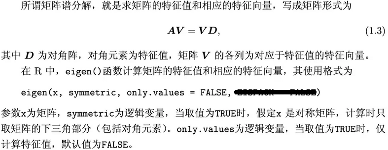

非对称矩阵的特征根经常包含复数。

```r
A <- matrix(c(1, 2, 3, 1, 3, 5, 2, 4, 7), nrow = 3); A
```

```
##      [,1] [,2] [,3]
## [1,]    1    1    2
## [2,]    2    3    4
## [3,]    3    5    7
```

```r
eigen(A)
## eigen() decomposition
## $values
## [1] 10.7290730+0.0000000i  0.1354635+0.2735952i  0.1354635-0.2735952i
##
## $vectors
##               [,1]                  [,2]                  [,3]
## [1,] -0.2235212+0i  0.7414696+0.0000000i  0.7414696+0.0000000i
## [2,] -0.4929916+0i -0.0762117-0.4934161i -0.0762117+0.4934161i
## [3,] -0.8408314+0i -0.2824079+0.3481393i -0.2824079-0.3481393i
```

对称矩阵的特征根都是实数。这时V是正交矩阵。

```r
## 这个矩阵对称
B <- crossprod(A); B
```

```
##      [,1] [,2] [,3]
## [1,]   14   22   31
## [2,]   22   35   49
## [3,]   31   49   69
```

```r
evdB <- eigen(B, symmetric = TRUE)

## 验证结果的正确性（简单粗暴）
with(evdB, vectors %*% diag(values) %*% t(vectors))
```

```
##      [,1] [,2] [,3]
## [1,]   14   22   31
## [2,]   22   35   49
## [3,]   31   49   69
```

```r
## 验证结果的正确性（巧用循环法则）
with(evdB, vectors %*% (values * t(vectors)))
```

```
##      [,1] [,2] [,3]
## [1,]   14   22   31
## [2,]   22   35   49
## [3,]   31   49   69
```

```r
## 验证V是正交矩阵
crossprod(evdB$vectors)
```

```
##               [,1]          [,2]         [,3]
## [1,]  1.000000e+00 -4.440892e-16 0.000000e+00
## [2,] -4.440892e-16  1.000000e+00 2.775558e-17
## [3,]  0.000000e+00  2.775558e-17 1.000000e+00
```

```r
tcrossprod(evdB$vectors)
```

```
##      [,1]          [,2]          [,3]
## [1,]    1  0.000000e+00  0.000000e+00
## [2,]    0  1.000000e+00 -3.469447e-16
## [3,]    0 -3.469447e-16  1.000000e+00
```

如果选择不计算V矩阵，成员`vectors`将为`NULL`.

```r
eigen(B, symmetric = TRUE, only.values = TRUE)
```

```
## $values
## [1] 117.78782603   0.15866651   0.05350746
##
## $vectors
## NULL
```

## 1.4.8-4 正定方阵的Cholesky分解

正定方阵：**满秩的**对称矩阵。

```r
A
```

```
##      [,1] [,2] [,3]
## [1,]    1    1    2
## [2,]    2    3    4
## [3,]    3    5    7
```

```r
## 这个矩阵对称且满秩，可以作Cholesky分解
B1 <- crossprod(A); B1
```

```
##      [,1] [,2] [,3]
## [1,]   14   22   31
## [2,]   22   35   49
## [3,]   31   49   69
```

```r
## 分解出来的上三角因子
U1 <- chol(B1)

## 验证分解的正确性
crossprod(U1)
```

```
##      [,1] [,2] [,3]
## [1,]   14   22   31
## [2,]   22   35   49
## [3,]   31   49   69
```

```r
## 这个矩阵对称但不满秩，不可以作Cholesky分解
B2 <- crossprod(A[-3, ]); B2
```

```
##      [,1] [,2] [,3]
## [1,]    5    7   10
## [2,]    7   10   14
## [3,]   10   14   20
```

```r
## 分解发生错误
U2 <- chol(B2)
```

```
## Error in chol.default(B2): the leading minor of order 3 is not positive definite
```

# 作业

1. [不提交] 在上机课上运行本课所有代码；
2. [提交] 课本56页，第13、14、15、16题。